# Los Angeles County Covid-19 Analysis

Marc Los Huertos

04 July, 2020

# 1 Introduction

As I have watched the Covid-19 pandemic, I decided that I was going to process the data on my own and see of I could confirm trends articulated by state and federal agencies. From what I can tell, each region has it’s own timeline and trajectory based municipal responses and state mandates. Thus, I took some time to drill into the LA context.

## 1.1 Disclaimer

This is not peer reviewed work and well outside my typical professional work – but these mussings are mostly to help me understand what’s going on, but if others find this useful, please analyze the data for yourself to confirm my results. If you found something amiss with my analyses, please let me know and I’ll fix it ASAP.

# 2 Data Source

I have been using the [data hosted on github](https://github.com/CSSEGISandData/COVID-19), entitled Novel Corona-virus (COVID-19) Cases and provided by Johns Hopkins University, Center for Systems Science and Engineering.

# 3 Work flow – Data Wrangling

First, I create a list of daily reports and combined them into a single csv. Unfortunately, the folks curating the data have been terribly inconsistent in the with their data records as columns are added and inconsistently named. Unfortunately, reading the data into R took 5 hours because there were at least three different file structures, but should have taken 5 minutes.

Secondly, I needed to replace missing data with zeros and reformat the strings to numbers. I also changed the variable for the date into something R could actually do something with, i.e. from a character string to a date format.

```r
Daily$Confirmed=as.numeric(Daily$Confirmed)
Daily$Deaths[is.na(Daily$Deaths)]=0; Daily$Deaths <- as.numeric(Daily$Deaths)
Daily$lnConfirmed = log(Daily$Confirmed)
Daily$Recovered = as.numeric(Daily$Recovered)
Daily$Date= as.Date(as.character(Daily$Date), format='%m-%d-%Y')

str(Daily$Date)
```

```
##  Date[1:356228], format: "2020-01-22" "2020-01-22" "2020-01-22" "2020-01-22" "2020-01-22" ...
```

# 4 Current Conditions

## 4.1 Confirmed Cases in Southern California

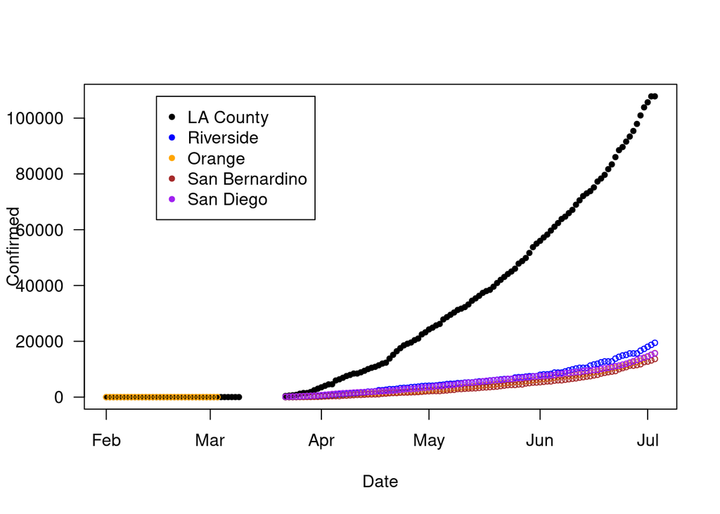

Figure 4.1: Confirmed Cases in Southern California County (Source JHU-CSSE)

## 4.2 Early Days

I find it ironic that the data are missing early in the outbreak – First, the public health infrastructure was completely unprepared to make timely tracking. Which speaks to an even more found problem — Had the federal government really planned effectively, these early cases could have been tracked much more effectively. For two weeks the values seem to be missing.

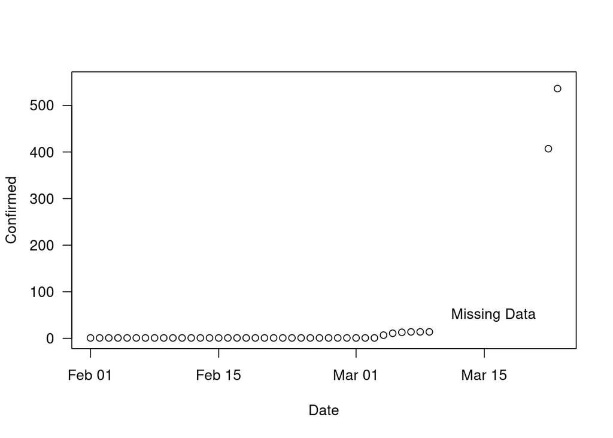

Figure 4.2: Early Records of Confirmed Cases of Covid-19 in LA County

```r
plot(Confirmed~Date, data=LA[LA$Date<="2020-03-23",], las=1, ylim=c(0,550), ty='p')
text(as.Date("2020-03-16"), 50, "Missing Data")
```

### 4.2.1 Filling in the Missing Data w/ LA County Public Health Reports

I found press releases by the County to have some of the missing data:

- 3/09/2020 = 16 cases (github reported 14)
- 3/10/2020 = 17 cases, but missing LB and Pasadena
- 3/11/2020 = 27 cases
- 3/12/2020 = 32 cases
- 3/13/2020 = 40 cases
- 3/14/2020 = 53 cases
- 3/15/2020 = 69 cases
- 3/16/2020 = 94 cases
- 3/17/2020 = 144 cases
- 3/18/2020 = 190 cases
- 3/19/2020 = 231 cases
- 3/20/2020 = 292 cases
- 3/21/2020 = 351 cases
- 3/22/2020 = 409 cases (corrected as 407 on the 23rd, same as github)
- 3/23/2020 = 536 cases (90 hospitalized) same as github

Missing or incorrect data on Github site from the weekend of the March 28/29, April 4, April 11/12 based on the County Health Department Webpage (noon on each day).

```r
LA$Confirmed[LA$Date=="2020-03-28"] = 1829
LA$Confirmed[LA$Date=="2020-03-29"] = 2136
LA$Confirmed[LA$Date=="2020-04-04"] = 5277
LA$Confirmed[LA$Date=="2020-04-11"] = 8873
LA$Confirmed[LA$Date=="2020-04-12"] = 9162
LA = LA[order(LA$Date),]
```

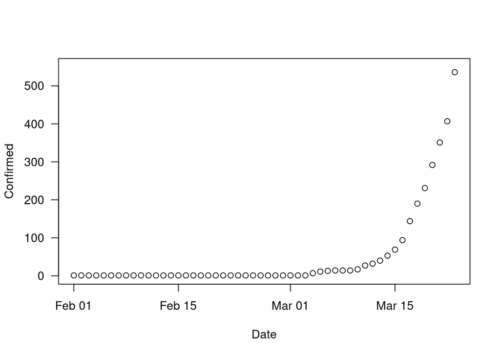

Figure 4.3: Early Records of Confirmed Cases of Covid-19 in LA County

```r
plot(Confirmed~Date, data=LA[LA$Date<="2020-03-23",], las=1, ylim=c(0,550), ty='p')
```

# 5 Per Capita Cases Comparisons

## 5.1 County Population Sizes

Counties vary in size, so the number of cases in a county isn’t a good measure of prevalence and spread. Epidiologists generally measure cases relative to constant populaitions size – e.g. per 1,000, 10,000, 100,000, etc – depending on prevalence. For our case, we’ll use the standard for covid, which is per 10,000.

In addition, with confirmed per 10,000 we can compare counties.

```r
CA$County <- CA$Admin2
densities = read.csv("/home/CAMPUS/mwl04747/github/test/Epidemiology/County.Densities.csv", header=FALSE)
names(densities)=c("County", "Density")
CA_densities = merge(CA, densities)
CA_densities$Death.d = as.numeric(CA_densities$Deaths) / CA_densities$Density
populations = read.csv("/home/CAMPUS/mwl04747/github/test/Epidemiology/CA_County_Population.csv")
CA_pop = merge(CA_densities, populations)
CA_pop$Death.r <- CA_pop$Deaths/CA_pop$Population*10000
CA_pop$Confirmed.r <- CA_pop$Confirmed/CA_pop$Population*10000

rm(populations, densities, county)
```

## 5.2 Selected Counties to Compare

There are 58 counties in CA, too many to view at once. So, I selected a few SoCal, BayArea, and rural counities to compare.

```r
Selected = subset(CA_pop, subset=(County=="Los Angeles" | County=="Orange" | County=="San Bernardino" | County=="San Diego" | County=="Santa Cruz" | County=="San Francisco" | County=="Santa Clara" | County=="Del Norte" | County=="Monterey" | County=="Mono" | County=="San Luis Obispo"))
```

## 5.3 Confirmed Cases and Deaths by County

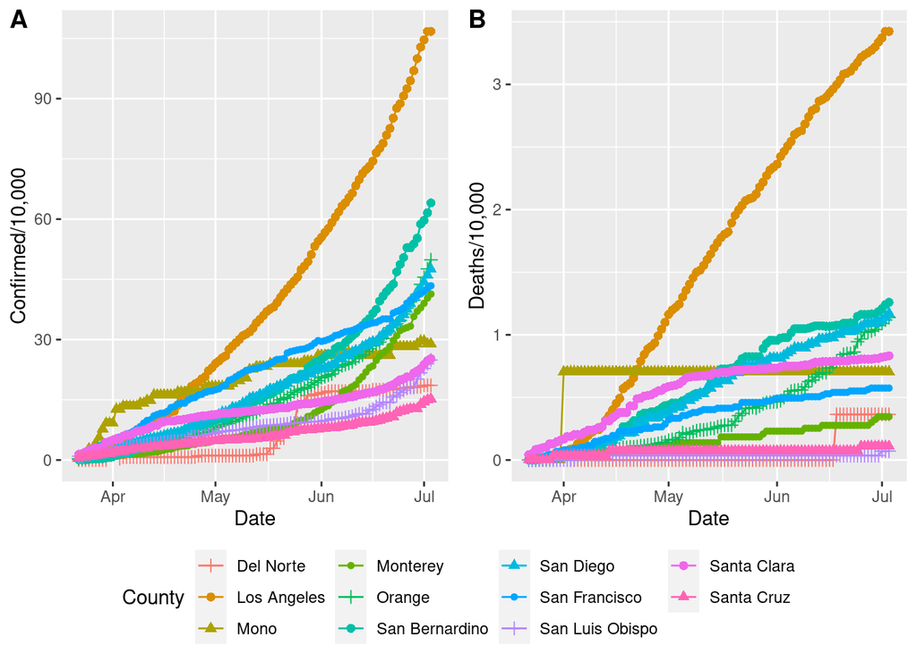

```r
C <- ggplot(Selected, aes(x = Date, y = Confirmed.r, color = County)) + geom_line() + geom_point(aes(shape=County), size=2) + scale_shape_manual(values=c(3, 16, 17, 20, 3, 16, 17, 20, 3, 16, 17)) + labs(y = "Confirmed/10,000")

D.r <- ggplot(Selected, aes(x = Date, y = Death.r, color = County)) + geom_line() + geom_point(aes(shape=County), size=2) + scale_shape_manual(values=c(3, 16, 17, 20, 3, 16, 17, 20, 3, 16, 17)) + labs(y = "Deaths/10,000")

library(ggpubr)

figure <- ggarrange(C, D.r,
    labels = c("A", "B"),
    ncol = 2, nrow = 1,
    common.legend = TRUE, legend = "bottom")
figure
```

The prevalence for confirmed cases and mortality are the highest in Los Angeles County. However, cases in San Bernardino has climbed rapidly in June, although mortality has been relatively stable.

Some counties have had very low mortality, which suggest that fewer people with pre-existing conditions have been infected or the number of deaths has not been accurately recorded.

## 5.4 Density does not explain county differences

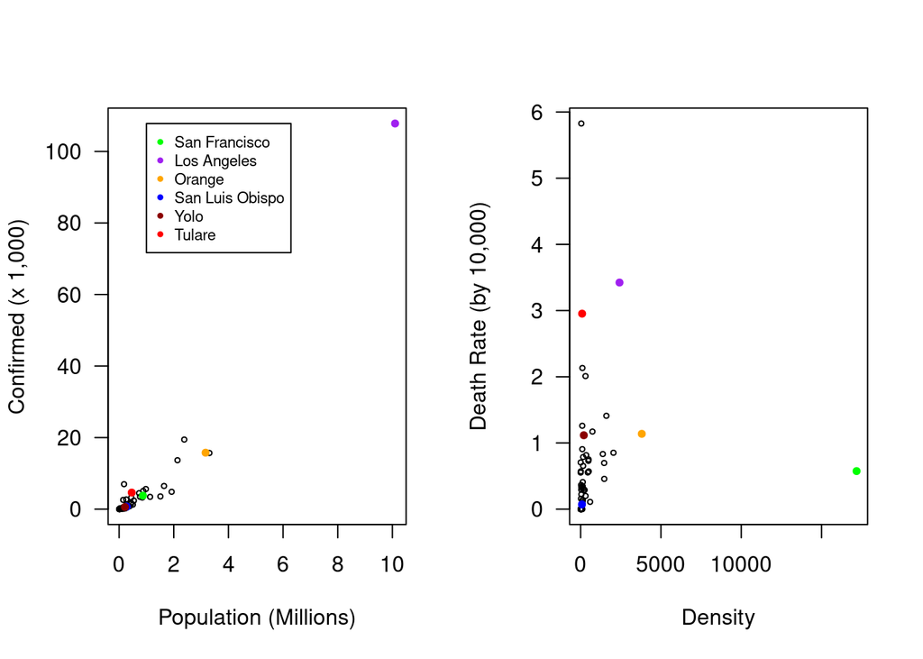

As noted above, Los Angeles has been hit the hardest – with numbers well above the other counties. Nevertless, there is a pretty good relationship between the number of confirmed and the size of the county.

However, when evaluate the per capita rates with density, we found some odd results. Namely, San Francisco is an outlier – high density but low mortality. Meanwhile, some rural counties, e.g. Tulare and one unidentified county, that have very high morality rates in spite of low county density.

This has been explained with data in New York, where the density of the city isn’t a good predictor of infection and mortality rates, but the relative density of individuals in the city, which is correlated with income. More income, the more socially distance you can afford.

## 5.5 Changing Rates by County

However, these pattern of infection and mortality rates is dynamic. In other words, the rates have changed with time.

Confirmed Cases by rank ordered

| County | Confirmed | June | May | April | % Confirmed per capita | % per capita–June | % per capita–May | % per capita–April |
| --- | --- | --- | --- | --- | --- | --- | --- | --- |
| Imperial | 6979.00 | 1751.00 | 333.00 | 38.00 | 3.87 | 0.97 | 0.18 | 0.02 |
| Kings | 2583.00 | 1122.00 | 123.00 | 4.00 | 1.72 | 0.75 | 0.08 | 0.00 |
| Los Angeles | 107806.00 | 56011.00 | 24262.00 | 3518.00 | 1.07 | 0.55 | 0.24 | 0.03 |
| Marin | 2710.00 | 483.00 | 237.00 | 107.00 | 1.04 | 0.19 | 0.09 | 0.04 |
| Tulare | 4627.00 | 1897.00 | 680.00 | 45.00 | 1.00 | 0.41 | 0.15 | 0.01 |
| Riverside | 19450.00 | 7982.00 | 4079.00 | 371.00 | 0.82 | 0.33 | 0.17 | 0.02 |
| Santa Barbara | 3261.00 | 1649.00 | 506.00 | 99.00 | 0.73 | 0.37 | 0.11 | 0.02 |
| San Bernardino | 13676.00 | 5355.00 | 2113.00 | 183.00 | 0.64 | 0.25 | 0.10 | 0.01 |

San Francisco, has a very high density – but it’s mortality rates are suprisingly low. On the other hand, LA has a mortality rate very high – even relative to it’s density.

But the death rates include some surprises – Tulare County (2.95) and Yolo County (1.12). These are surpringly high!

| County | Deaths | June | May | Death Rate–April | Death.r | Death Rate–June | Death Rate–May | Death Rate–April.1 |
| --- | --- | --- | --- | --- | --- | --- | --- | --- |
| Imperial | 105.00 | 29.00 | 9.00 | 0.00 | 5.83 | 1.61 | 0.50 | 0.00 |
| Los Angeles | 3457.00 | 2386.00 | 1174.00 | 0.06 | 3.42 | 2.36 | 1.16 | 0.06 |
| Tulare | 136.00 | 89.00 | 40.00 | 0.02 | 2.95 | 1.93 | 0.87 | 0.02 |
| Kings | 32.00 | 5.00 | 1.00 | 0.00 | 2.13 | 0.33 | 0.07 | 0.00 |
| Riverside | 479.00 | 331.00 | 156.00 | 0.05 | 2.01 | 1.39 | 0.65 | 0.05 |
| San Mateo | 108.00 | 84.00 | 51.00 | 0.13 | 1.41 | 1.10 | 0.67 | 0.13 |
| San Bernardino | 269.00 | 204.00 | 94.00 | 0.03 | 1.26 | 0.96 | 0.44 | 0.03 |
| San Diego | 387.00 | 269.00 | 124.00 | 0.03 | 1.17 | 0.81 | 0.38 | 0.03 |

# 6 Growth Rate of Confirmed Cases

## 6.1 Determine Doubling Rate

Doubling rate is an estimate of how many days (in this case) we have seen the confirmed cases double.

The analysis is based on the slope of the natural log of the confirmed cases and the slope. Of course, the model is wildly inaccurate if you selected the first start date to model. Obviously, this is tricky, since we know the data are crap in the early (?) part of the pandemic.

Even after skipping the first 32 observations where there were no cases, the model demonstrates the much doubling rate has changed through the pandemic.

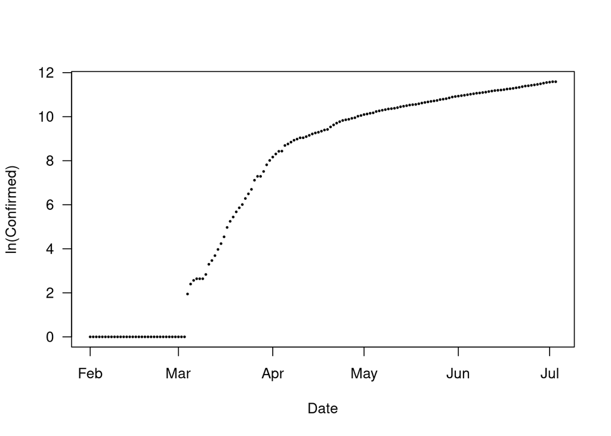

Because the rate is so dynamic, I have not figured out how to estimate it very well, but have noticed that I can manually break it up into chunks with some success.

## 6.2 Daily Cases, Deaths

```r
CA$New = NA; CA$Week = NA

# Subset counties - remove Modoc and Lassen
CA = subset(CA, subset=(Admin2!="Modoc" | Admin2!="Lassen"))
CA = CA[order(CA$Date),]
counties <- unique(CA$Admin2)[-59]

# Weekly Changes
for(i in 1:length(counties)){
  tmp = subset(CA, subset=(Admin2==counties[i]))$Confirmed
  new = sapply(1:length(tmp), function(x) tmp[x+1]) - tmp
  new = c(NA, new[-length(new)])
  week = round((1:length(new)+3.5)/7, 0)
  CA$New[CA$Admin2==counties[i]] = new
  CA$Week[CA$Admin2==counties[i]] = week
}

Slopes = data.frame(County=NA, Week=NA, Slope=NA)
#Daily$New <- sapply(1:nrow(Daily), function(x) Daily$Confirmed[x+1])
i = 5; j=10
for(i in 1:max(CA$Week, na.rm=T)){
  for(j in 1:length(counties)){
m1 = lm(New ~ Date, CA[CA$Week==i & CA$Admin2==counties[j],])

Slopes = rbind(Slopes,
               data.frame(County=counties[j], Week=i, Slope= as.numeric(round(coef(m1)[2],2))))

  }}


CA %>%
  group_by(Admin2) %>%
  do(lm(lnConfirmed~Date, data=.) %>% coef %>% as_tibble)
```

## 6.3 Comparing Doubling Rate Changes by SoCal Counties

The doubling rate, i.e. the number of days before the number of confirmed cases, is a good measure of the near term changes we can expect for Covid-19. How quickly the doubling rate might decrease as a function of municipal and state recommendations and orders is quite difficult to estimate. It depends on ‘shelter-in-place’ compliance, the number of people getting the virus and the testing rate. I suspect it will be uneven, temporally and spatially.

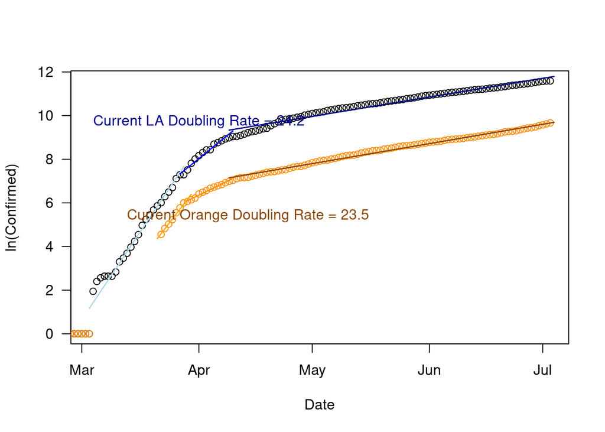

# 7 New Cases – The Critical Measure of Leveling the Curve

new cases

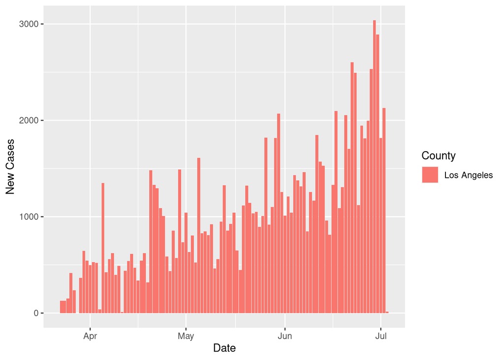

```r
library(dplyr)
CA <-
    CA %>%
    group_by(County) %>%
    mutate(Confirmed.lag = dplyr::lag(Confirmed, n = 1, default = NA))

CA$New <- CA$Confirmed - CA$Confirmed.lag

ggplot(CA[CA$County=="Los Angeles",], aes(x = Date, y=New)) + geom_col(aes(fill = County)) + #geom_point(aes(shape=County), size=2) + #scale_shape_manual(values=c(3, 16, 17, 20, 3, 16, 17, 20, 3, 16, 17)) +
labs(y = "New Cases")
```